# Downloading Large Data Example

Load libraries:

```r
library(caladaptr)
library(sf)
library(dplyr)
library(tictoc)   # used to time how long functions take
```

The first step is to figure out which of >8000 census tracts in Cal-Adapt are in California. We can grab the census tract boundaries using `ca_aoipreset_geom()`:

```r
tracts_fips_all  <- ca_aoipreset_geom("censustracts") %>%
  st_drop_geometry() %>%
  select(tract)
str(tracts_fips_all)
```

```
'data.frame':   8034 obs. of  1 variable:
 $ tract: num  6e+09 6e+09 6e+09 6e+09 6e+09 ...
```

We can pull out the California tracts based on the first two numbers of the FIPS code (which represents the state).

```r
tracts_ca <- tracts_fips_all %>%
  mutate(tract_chr = as.character(tract)) %>%
  filter(grepl("^60", tract_chr)) %>%
  pull(tract)
str(tracts_ca)
```

```
 num [1:7680] 6e+09 6e+09 6e+09 6e+09 6e+09 ...
```

Next, we construct the API request:

```r
cap <- ca_loc_aoipreset(type="censustracts", idfld = "tract", idval = tracts_ca) %>%
  ca_gcm(gcms[1:4]) %>%
  ca_scenario(c("rcp85")) %>%
  ca_period("day") %>%
  ca_years(start = "2035-01-01", end = "2039-12-31") %>%
  ca_cvar("tasmax") %>%
  ca_options(spatial_ag = "max")
cap
```

```
Cal-Adapt API Request
Location(s):
  AOI Preset: censustracts
  tract(s): 6001400100, 6001400200, 6001400300, ...
Variable(s): tasmax
Temporal aggregration period(s): day
GCM(s): HadGEM2-ES, CNRM-CM5, CanESM2, MIROC5
Scenario(s): rcp85
Slug(s): NA
Dates: 2035-01-01 to 2039-12-31
Options:
  spatial ag: max
  temporal ag (add'l): NA
```

Let’s plot the API request object to verify we got the right areas:

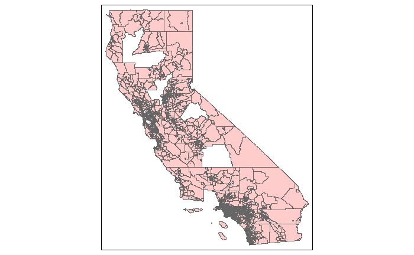

```r
plot(cap, static = TRUE)
```

```r
cap
```

[output not shown]

Now, we’re ready to fetch the data.

Tip: Use `debug = TRUE` to show individual API calls instead of a progress bar (which in this case moves very slowly). This doesn’t work terribly well in a R Notebook but works well when the command is run from a script or console.

If the process is interrupted, you can just run the command again and it should pick-up where it left off.

```r
tracts_daily_tasmax_tbl <- ca_getvals(cap, debug = TRUE, db_fn = my_sqlite, db_tbl = "tracts_day_tasmax")
```

[output not shown]